# Data Mining - Nuerual Netowrk and CART Model

## Neural Network Model

```r
library(neuralnet)
```

Building of Neural Network Model: Pre-Req:

1. All the variables for building the neural network model should be continuous and not discrete in nature. So all the categorical variables from the dataset to be converted to discrete variables
2. Scaling of data is also important for Neural network model build for the cost function to be effective So both the above test steps to be performed before building the Neural network Model

[output not shown]

```r
eadf.dev$BusinessTravel <- as.numeric(eadf.dev$BusinessTravel)
eadf.dev$EducationField <- as.numeric(eadf.dev$EducationField)
eadf.dev$OverTime <- as.numeric(eadf.dev$OverTime)
eadf.dev$JobRole <- as.numeric(eadf.dev$JobRole)
#eadf.dev$Gender <- as.numeric(eadf.dev$Gender)
eadf.dev$MaritalStatus <- as.numeric(eadf.dev$MaritalStatus)

eadf.dev$Attrition <- ifelse(eadf.dev$Attrition =="No",0,1)
```

On Converting by assigning the individual level scores, the neural network had a validation Error due to the difference in the levels between various attributes. Hence generic transformation is done for both Training and Test Data set

```r
eadf.dev.scale <- scale(eadf.dev[-c(2)])

eadf.dev.scale <- cbind(eadf.dev[2], eadf.dev.scale)
```

```r
eadf.nm <- neuralnet(formula = Attrition ~ ., data = eadf.dev.scale[-2],
                     hidden = 3,
                 err.fct = "sse",
                 linear.output = FALSE,
                 lifesign = "full",
                 lifesign.step = 100,
                 threshold = 0.1,
                 stepmax = 2000
                 )
```

```
hidden: 3    thresh: 0.1    rep: 1/1    steps:     100	min thresh: 0.548853671706645
                                                   200	min thresh: 0.338581103600796
                                                   300	min thresh: 0.29292908980422
                                                   400	min thresh: 0.243680195546977
                                                   500	min thresh: 0.191042318569891
                                                   600	min thresh: 0.172530257601551
                                                   700	min thresh: 0.172530257601551
                                                   800	min thresh: 0.172530257601551
                                                   900	min thresh: 0.17122379759449
                                                  1000	min thresh: 0.15600658978494
                                                  1100	min thresh: 0.124615960539502
                                                  1200	min thresh: 0.123708990774762
                                                  1300	min thresh: 0.116485329058647
                                                  1400	min thresh: 0.114634730037286
                                                  1500	min thresh: 0.111527177718616
                                                  1600	min thresh: 0.100230452174411
                                                  1700	min thresh: 0.100230452174411
                                                  1800	min thresh: 0.100230452174411
                                                  1871	error: 75.60016	time: 1.9 secs
```

```r
eadf.dev$Prob = eadf.nm$net.result[[1]]

quantile(eadf.nm$net.result[[1]] , c(0,1,5,10,25,50,75,90,95,99,100)/100)
```

**0%**

1.13447908713428e-16

**1%**

1.13447913476054e-16

**5%**

1.1346585482593e-16

**10%**

1.14970363223404e-16

**25%**

2.56763899878553e-13

**50%**

7.96417609880843e-07

**75%**

0.0577832947689848

**90%**

0.441701395532099

**95%**

0.976164182833919

**99%**

0.999999999473326

**100%**

0.999999999604039

Converting and scalling the Test data

```r
eadf.test$BusinessTravel <- as.numeric(eadf.test$BusinessTravel)
eadf.test$EducationField <- as.numeric(eadf.test$EducationField)
eadf.test$OverTime <- as.numeric(eadf.test$OverTime)
eadf.test$JobRole <- as.numeric(eadf.test$JobRole)
#eadf.test$Gender <- as.numeric(eadf.test$Gender)
eadf.test$MaritalStatus <- as.numeric(eadf.test$MaritalStatus)


eadf.test$Attrition <- ifelse(eadf.test$Attrition =="No",0,1)

eadf.test.scale <- scale(eadf.test[-c(2)])

eadf.test.scale <- cbind(eadf.test[2], eadf.test.scale)
```

Prediciting using the Nerual network model

```r
eadf.test$probnn <-compute (eadf.nm,eadf.test.scale[,-2])$net.result
```

```r
eadf.test$predictionnn <- ifelse(eadf.test$prob>0.5,1,0)
```

```r
confusionnm <- table(eadf.test$Attrition,eadf.test$predictionnn)

confusionnm

TP <- confusionnm[2, 2]
TN = confusionnm[1, 1]
FP = confusionnm[1, 2]
FN = confusionnm[2, 1]

ClassificationAccuracynm <- round((TP + TN) /(TP + TN + FP + FN),4)
sensitivitynm <- round(TP / (FN + TP),4)
specificitynm <-round(TN / (TN + FP),4)
precisionnm  <- round(TP / (TP + FP),4)

ClassificationAccuracynm
sensitivitynm
specificitynm
precisionnm
```

```
      0   1
  0 716  24
  1  77  65
```

0.8855

0.4577

0.9676

0.7303

```r
## deciling code
decile <- function(x){
  deciles <- vector(length=10)
  for (i in seq(0.1,1,.1)){
    deciles[i*10] <- quantile(x, i, na.rm=T)
  }
  return (
    ifelse(x<deciles[1], 1,
    ifelse(x<deciles[2], 2,
    ifelse(x<deciles[3], 3,
    ifelse(x<deciles[4], 4,
    ifelse(x<deciles[5], 5,
    ifelse(x<deciles[6], 6,
    ifelse(x<deciles[7], 7,
    ifelse(x<deciles[8], 8,
    ifelse(x<deciles[9], 9, 10
    ))))))))))
}
```

```r
eadf.test$deciles <- decile(eadf.test$probnn)
tmp_DT = data.table(eadf.test)
rank <- tmp_DT[, list(
  cnt = length(Attrition),
  cnt_resp = sum(Attrition),
  cnt_non_resp = sum(Attrition == 0)) ,
  by=deciles][order(-deciles)]
rank$rrate <- round (rank$cnt_resp / rank$cnt,2);
rank$cum_resp <- cumsum(rank$cnt_resp)
rank$cum_non_resp <- cumsum(rank$cnt_non_resp)
rank$cum_rel_resp <- round(rank$cum_resp / sum(rank$cnt_resp),2);
rank$cum_rel_non_resp <- round(rank$cum_non_resp / sum(rank$cnt_non_resp),2);
rank$ks <- abs(rank$cum_rel_resp - rank$cum_rel_non_resp);
```

```r
print(rank)
```

```
    deciles cnt cnt_resp cnt_non_resp rrate cum_resp cum_non_resp cum_rel_resp
 1:      10  89       65           24  0.73       65           24         0.46
 2:       9  88       30           58  0.34       95           82         0.67
 3:       8  88       11           77  0.12      106          159         0.75
 4:       7  88        6           82  0.07      112          241         0.79
 5:       6  88        3           85  0.03      115          326         0.81
 6:       5  88        2           86  0.02      117          412         0.82
 7:       4  88       13           75  0.15      130          487         0.92
 8:       3  88        5           83  0.06      135          570         0.95
 9:       2  88        3           85  0.03      138          655         0.97
10:       1  89        4           85  0.04      142          740         1.00
    cum_rel_non_resp   ks
 1:             0.03 0.43
 2:             0.11 0.56
 3:             0.21 0.54
 4:             0.33 0.46
 5:             0.44 0.37
 6:             0.56 0.26
 7:             0.66 0.26
 8:             0.77 0.18
 9:             0.89 0.08
10:             1.00 0.00
```

```r
gininm = ineq(eadf.test$predictionnn, type="Gini")
pred <- ROCR::prediction(eadf.test$probnn, eadf.test$Attrition)
perf <- performance(pred, "tpr", "fpr")
KSnm <- max(attr(perf, 'y.values')[[1]]-attr(perf, 'x.values')[[1]])
auc <- performance(pred,"auc");
aucnm <- as.numeric(auc@y.values)

KSnm <- round(KSnm,4)
aucnm <- round(aucnm,4)
gininm <- round(gininm,4)

KSnm
aucnm
gininm
```

0.581

0.8211

0.8991

# Bulid a CART Model

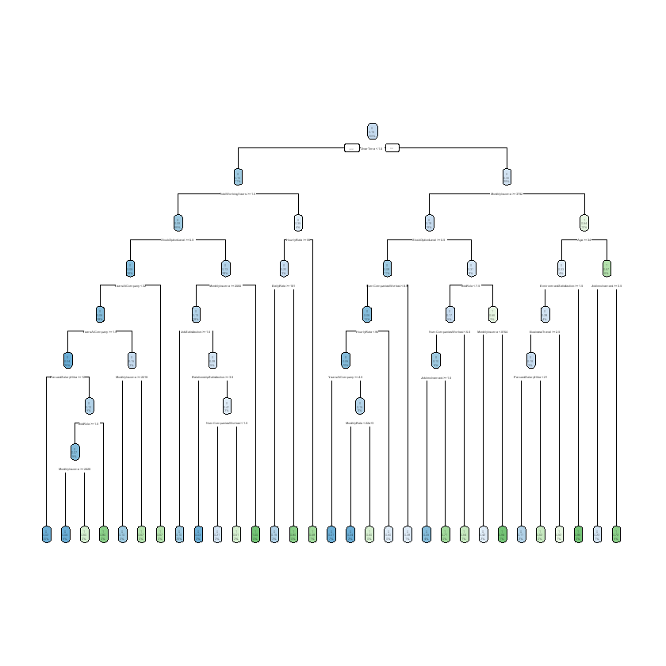

```r
r.ctrl = rpart.control(minsplit=50, minbucket = 5, cp = 0, xval = 10)

eadf.cart <- rpart(formula =  Attrition~ ., data = eadf.dev [-26], method = "class", control = r.ctrl)

rpart.plot(eadf.cart)
```

```
Classification tree:
rpart(formula = Attrition ~ ., data = eadf.dev[-26], method = "class",
    control = r.ctrl)

Variables actually used in tree construction:
 [1] Age                      BusinessTravel           DailyRate
 [4] EnvironmentSatisfaction  HourlyRate               JobInvolvement
 [7] JobRole                  JobSatisfaction          MonthlyIncome
[10] MonthlyRate              NumCompaniesWorked       OverTime
[13] PercentSalaryHike        RelationshipSatisfaction StockOptionLevel
[16] TotalWorkingYears        YearsAtCompany

Root node error: 332/2058 = 0.16132

n= 2058

          CP nsplit rel error  xerror     xstd
1  0.0421687      0   1.00000 1.00000 0.050261
2  0.0210843      3   0.87349 0.93675 0.048940
3  0.0150602      4   0.85241 0.92470 0.048680
4  0.0120482      7   0.80723 0.88253 0.047747
5  0.0090361     11   0.75000 0.88554 0.047815
6  0.0080321     13   0.73193 0.89458 0.048017
7  0.0070281     16   0.70783 0.88855 0.047882
8  0.0045181     19   0.68675 0.89458 0.048017
9  0.0037651     21   0.67771 0.90663 0.048285
10 0.0030120     25   0.66265 0.90663 0.048285
11 0.0015060     26   0.65964 0.91867 0.048549
12 0.0000000     30   0.65361 0.95181 0.049261
```

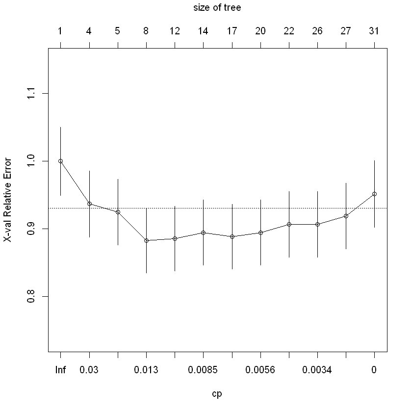

```r
## to find how the tree performs and derive cp value
printcp(eadf.cart)
plotcp(eadf.cart)
```

```
Classification tree:
rpart(formula = Attrition ~ ., data = eadf.dev[-26], method = "class",
    control = r.ctrl)

Variables actually used in tree construction:
 [1] Age                     DailyRate               EnvironmentSatisfaction
 [4] HourlyRate              JobInvolvement          JobRole
 [7] MonthlyIncome           NumCompaniesWorked      OverTime
[10] StockOptionLevel        TotalWorkingYears

Root node error: 332/2058 = 0.16132

n= 2058

         CP nsplit rel error  xerror     xstd
1 0.0421687      0   1.00000 1.00000 0.050261
2 0.0210843      3   0.87349 0.93675 0.048940
3 0.0150602      4   0.85241 0.92470 0.048680
4 0.0120482      7   0.80723 0.88253 0.047747
5 0.0090361     11   0.75000 0.88554 0.047815
6 0.0085000     13   0.73193 0.89458 0.048017
```

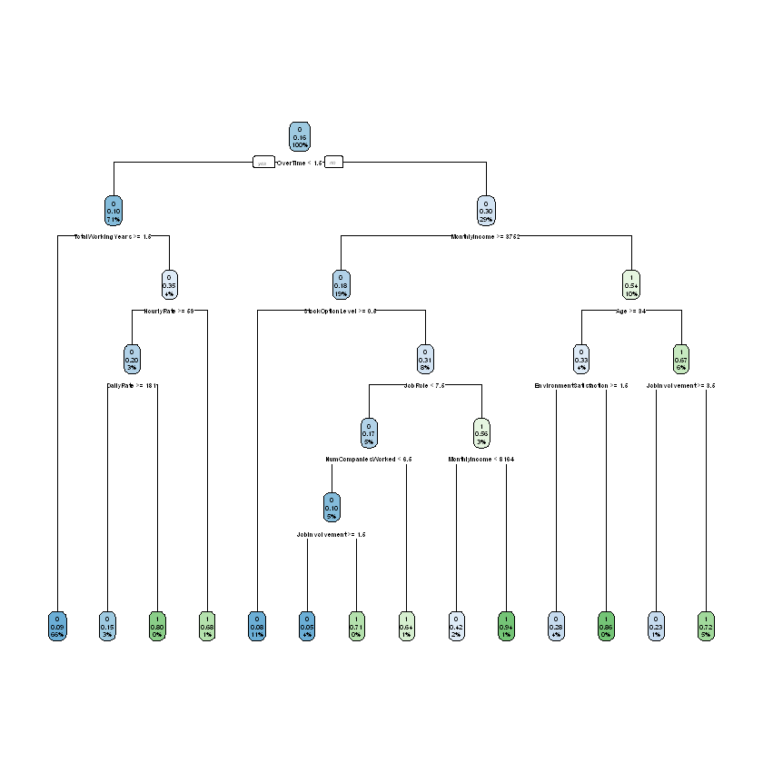

```r
eadf.prcart<- prune(eadf.cart, cp= 0.0085 ,"CP")
printcp(eadf.prcart)
rpart.plot(eadf.prcart)
```

```r
eadf.test$predict.class <- predict(eadf.prcart, eadf.test, type="class")
eadf.test$predict.score <- predict(eadf.prcart, eadf.test)

confusioncar <- table(eadf.test$Attrition, eadf.test$predict.class)
confusioncar

TP <- confusioncar[2, 2]
TN = confusioncar[1, 1]
FP = confusioncar[1, 2]
FN = confusioncar[2, 1]

ClassificationAccuracycar <- round((TP + TN) /(TP + TN + FP + FN),4)
sensitivitycar <- round(TP / (FN + TP),4)
specificitycar <-round(TN / (TN + FP),4)
precisioncar  <- round(TP / (TP + FP),4)

ClassificationAccuracycar
sensitivitycar
specificitycar
precisioncar
```

```
      0   1
  0 708  32
  1  91  51
```

0.8605

0.3592

0.9568

0.6145

```r
ginicar = ineq(eadf.test$predict.score[,2], type="Gini")

predcar <- ROCR::prediction(eadf.test$predict.score[,2], eadf.test$Attrition)
perfcar <- performance(predcar, "tpr", "fpr")
KScar <- max(attr(perfcar, 'y.values')[[1]]-attr(perfcar, 'x.values')[[1]])
auccar <- performance(predcar,"auc");
aucar <- as.numeric(auccar@y.values)

ginicar<- round(ginicar,4)
KScar <- round (KScar,4)
aucar <- round(aucar,4)
ginicar
KScar
aucar
```

0.4206

0.4184

0.7115

```r
Modelmeasures <- data.frame (measurename = c("ClassificationAccuracy","sensitivity","specificity","precision","KS","AUC","Gini" ),
                             Neuralnetworks = c (ClassificationAccuracynm,sensitivitynm,specificitynm,precisionnm,KSnm,aucnm,gininm),
                              cart= c (ClassificationAccuracycar,sensitivitycar,specificitycar,precisioncar,KScar,aucar,ginicar))
Modelmeasures
```

| measurename | Neuralnetworks | cart |
| --- | --- | --- |
| ClassificationAccuracy | 0.8855 | 0.8605 |
| sensitivity | 0.4577 | 0.3592 |
| specificity | 0.9676 | 0.9568 |
| precision | 0.7303 | 0.6145 |
| KS | 0.5810 | 0.4184 |
| AUC | 0.8211 | 0.7115 |
| Gini | 0.8991 | 0.4206 |

# Ensemble Averaging:Combining Neural Network and Decision Tree

```r
predic <- data.frame(pcart= eadf.test$predict.class,pnn =  as.factor(eadf.test$predictionnn) )

predic$ensmbleavg <- (as.numeric(predic$pcart)+as.numeric(predic$pnn)-2)/2

predic$enclass <- ifelse (predic$ensmbleavg > 0.5,1,0)

eadf.test$enclass <-predic$enclass

confusionen <- table(eadf.test$Attrition,eadf.test$enclass)

confusionen

TP <- confusionen[2, 2]
TN <- confusionen[1, 1]
FP <- confusionen[1, 2]
FN <- confusionen[2, 1]

ClassificationAccuracyen <- round((TP + TN) /(TP + TN + FP + FN),4)
sensitivityen <- round(TP / (FN + TP),4)
specificityen <- round(TN / (TN + FP),4)
precisionen <- round(TP / (TP + FP),4)

ClassificationAccuracyen
sensitivityen
specificityen
precisionen
```

```
      0   1
  0 734   6
  1 109  33
```

0.8696

0.2324

0.9919

0.8462

```r
Modelmeasures <- data.frame (measurename = c("ClassificationAccuracy","sensitivity","specificity","precision","KS","AUC","Gini" ),
                             Neuralnetworks = c (ClassificationAccuracynm,sensitivitynm,specificitynm,precisionnm,KSnm,aucnm,gininm),
                              cart= c (ClassificationAccuracycar,sensitivitycar,specificitycar,precisioncar,KScar,aucar,ginicar),
                              ensemple =c(ClassificationAccuracyen,sensitivityen,specificityen,precisionen,'NA','NA','NA'))
Modelmeasures
```

| measurename | Neuralnetworks | cart | ensemple |
| --- | --- | --- | --- |
| ClassificationAccuracy | 0.8855 | 0.8605 | 0.8696 |
| sensitivity | 0.4577 | 0.3592 | 0.2324 |
| specificity | 0.9676 | 0.9568 | 0.9919 |
| precision | 0.7303 | 0.6145 | 0.8462 |
| KS | 0.5810 | 0.4184 | NA |
| AUC | 0.8211 | 0.7115 | NA |
| Gini | 0.8991 | 0.4206 | NA |